[figure not shown]

# TokenAnalyst coding task

The code below shows how data was generated for completing the task

```python
import pandas as pd
import numpy as np
from matplotlib import pyplot as plt
```

# Generate first table

```python
import random

blocknumber=[]
#Create 8,000 instances for columns a,b,c
for x in range(8000):
    blocknumber.append(random.randint(1,3601))
```

```python
#Create new DataFrame
final_dataset = pd.DataFrame({'blockNumber':blocknumber})
```

```python
#balance range
balance=[]
for x in range(8000):
    balance.append(random.randint(0,3000))
```

```python
final_dataset['balance']=balance
address_list=['a','b','c','d','e','f','g']
address=[]
for x in range(8000):
    address.append(random.choice(address_list))
final_dataset['address']=address
#del final_dataset['address']
final_dataset['address'].value_counts()
```

```
c    1179
b    1172
f    1169
g    1164
a    1119
e    1102
d    1095
Name: address, dtype: int64
```

```python
final_dataset.head()
```

|  | blockNumber | balance | address |
| --- | --- | --- | --- |
| 0 | 2458 | 1673 | f |
| 1 | 3114 | 1031 | g |
| 2 | 936 | 1627 | f |
| 3 | 2213 | 1709 | b |
| 4 | 3361 | 990 | a |

```python
final_dataset.shape
```

```
(8000, 3)
```

```python
final_dataset.to_csv('balance_data_final.csv',index=False)
```

Table above represents table 1 (Block_data as part of the SQL query)

# Generate second table

```python
# b) There are 10 blocks per day for our dataset so blocks 1-10 will have timestamp
# 01-01-2018, while blocks 3641 - 3650 will have time-stamp 12/31/2018
import radar
import datetime
timestamp=[]
#generate sequential 10 copies per day between 01-01-2018 and 31-12-2018 x
for x in range(10000):
    timestamp.append(radar.random_datetime(
        start = datetime.datetime(year=2018, month=1, day=1),
        stop = datetime.datetime(year=2019, month=1, day=1)))
```

```python
start = datetime.datetime.strptime("01-01-2018", "%d-%m-%Y")
end = datetime.datetime.strptime("01-01-2019", "%d-%m-%Y")
date_generated = [start + datetime.timedelta(days=x) for x in range(0, (end-start).days)]
```

```python
for date in date_generated:
    date.strftime('%d-%m-%Y')
```

```python
#10 duplicates for each date
from itertools import repeat
date_generated=[x for date in date_generated for x in repeat(date, 10)]
```

```python
#generate 10 sequential blocks per day for each unique date in the timestamp column
blocknumber_two=[]
blocknumber_two = range(1,3651,1)
```

```python
timestamp_dataset=pd.DataFrame({'timestamp':date_generated,'blocknumber':blocknumber_two})
```

```python
timestamp_dataset.head(n=20)
```

|  | timestamp | blocknumber |
| --- | --- | --- |
| 0 | 2018-01-01 | 1 |
| 1 | 2018-01-01 | 2 |
| 2 | 2018-01-01 | 3 |
| 3 | 2018-01-01 | 4 |
| 4 | 2018-01-01 | 5 |
| 5 | 2018-01-01 | 6 |
| 6 | 2018-01-01 | 7 |
| 7 | 2018-01-01 | 8 |
| 8 | 2018-01-01 | 9 |
| 9 | 2018-01-01 | 10 |
| 10 | 2018-01-02 | 11 |
| 11 | 2018-01-02 | 12 |
| 12 | 2018-01-02 | 13 |
| 13 | 2018-01-02 | 14 |
| 14 | 2018-01-02 | 15 |
| 15 | 2018-01-02 | 16 |
| 16 | 2018-01-02 | 17 |
| 17 | 2018-01-02 | 18 |
| 18 | 2018-01-02 | 19 |
| 19 | 2018-01-02 | 20 |

```python
timestamp_dataset.tail(n=20)
```

|  | timestamp | blocknumber |
| --- | --- | --- |
| 3630 | 2018-12-30 | 3631 |
| 3631 | 2018-12-30 | 3632 |
| 3632 | 2018-12-30 | 3633 |
| 3633 | 2018-12-30 | 3634 |
| 3634 | 2018-12-30 | 3635 |
| 3635 | 2018-12-30 | 3636 |
| 3636 | 2018-12-30 | 3637 |
| 3637 | 2018-12-30 | 3638 |
| 3638 | 2018-12-30 | 3639 |
| 3639 | 2018-12-30 | 3640 |
| 3640 | 2018-12-31 | 3641 |
| 3641 | 2018-12-31 | 3642 |
| 3642 | 2018-12-31 | 3643 |
| 3643 | 2018-12-31 | 3644 |
| 3644 | 2018-12-31 | 3645 |
| 3645 | 2018-12-31 | 3646 |
| 3646 | 2018-12-31 | 3647 |
| 3647 | 2018-12-31 | 3648 |
| 3648 | 2018-12-31 | 3649 |
| 3649 | 2018-12-31 | 3650 |

```python
timestamp_dataset.shape
```

```
(3650, 2)
```

```python
timestamp_dataset.to_csv('timestamp_data.csv',index=False)
```

# Aggregate data chart following SQL query

```python
aggregate_data = pd.read_csv('aggregate_data.csv')
```

The end result of the SQL query is seen below, while the Python scripts below plot a line chart showing the change in ETH balance for each given address throughout 2018.

```python
aggregate_data.head()
```

|  | Address | Jan | Feb | Mar | Apr | May | Jun | Jul | Aug | Sep | Oct | Nov | Dec |
| --- | --- | --- | --- | --- | --- | --- | --- | --- | --- | --- | --- | --- | --- |
| 0 | e | 137711 | 171362 | 171201 | 146076 | 210458 | 122472 | 160065 | 138228 | 163924 | 122256 | 144225 | 155410 |
| 1 | g | 133846 | 133595 | 136377 | 99445 | 144859 | 148347 | 154684 | 135597 | 141347 | 139336 | 114404 | 118830 |
| 2 | a | 145647 | 133485 | 189703 | 169535 | 150190 | 162901 | 147216 | 155958 | 125093 | 142435 | 140456 | 146166 |
| 3 | f | 119950 | 135833 | 168556 | 125158 | 170639 | 142849 | 131851 | 137058 | 126984 | 166253 | 144703 | 113966 |
| 4 | c | 166920 | 97168 | 175547 | 135651 | 134370 | 137943 | 152668 | 140467 | 156822 | 136239 | 140155 | 139654 |

```python
aggregate_data_columns.remove('Address')
```

```python
aggregate_data_columns =pd.DataFrame(aggregate_data_columns)
```

```python
import datetime
dates = []
def last_day_of_month(any_day):
    next_month = any_day.replace(day=28) + datetime.timedelta(days=4)
    return next_month - datetime.timedelta(days=next_month.day)
for month in range(1, 13):
    dates.append(last_day_of_month(datetime.date(2018, month, 1)))
```

```python
aggregate_data_columns['dates']=dates
```

```python
aggregate_data_columns = aggregate_data_columns.rename(columns={0:'months'})
```

```python
aggregate_data_transposed = aggregate_data.T
```

```python
aggregate_data_transposed['months']=aggregate_data_transposed.index
```

```python
aggregate_data_transposed
```

|  | 0 | 1 | 2 | 3 | 4 | 5 | 6 | months |
| --- | --- | --- | --- | --- | --- | --- | --- | --- |
| Address | e | g | a | f | c | d | b | Address |
| Jan | 137711 | 133846 | 145647 | 119950 | 166920 | 112875 | 126032 | Jan |
| Feb | 171362 | 133595 | 133485 | 135833 | 97168 | 112339 | 134930 | Feb |
| Mar | 171201 | 136377 | 189703 | 168556 | 175547 | 169513 | 133312 | Mar |
| Apr | 146076 | 99445 | 169535 | 125158 | 135651 | 147914 | 168165 | Apr |
| May | 210458 | 144859 | 150190 | 170639 | 134370 | 134494 | 184194 | May |
| Jun | 122472 | 148347 | 162901 | 142849 | 137943 | 135165 | 139202 | Jun |
| Jul | 160065 | 154684 | 147216 | 131851 | 152668 | 146613 | 164558 | Jul |
| Aug | 138228 | 135597 | 155958 | 137058 | 140467 | 154277 | 151266 | Aug |
| Sep | 163924 | 141347 | 125093 | 126984 | 156822 | 131150 | 129314 | Sep |
| Oct | 122256 | 139336 | 142435 | 166253 | 136239 | 150468 | 143228 | Oct |
| Nov | 144225 | 114404 | 140456 | 144703 | 140155 | 163031 | 133192 | Nov |
| Dec | 155410 | 118830 | 146166 | 113966 | 139654 | 103601 | 139182 | Dec |

```python
aggregate_data_for_plot = pd.merge(aggregate_data_transposed,aggregate_data_columns,on='months',how='left')
```

```python
aggregate_data_for_plot
```

|  | 0 | 1 | 2 | 3 | 4 | 5 | 6 | months | dates |
| --- | --- | --- | --- | --- | --- | --- | --- | --- | --- |
| 0 | e | g | a | f | c | d | b | Address | NaN |
| 1 | 137711 | 133846 | 145647 | 119950 | 166920 | 112875 | 126032 | Jan | 2018-01-31 |
| 2 | 171362 | 133595 | 133485 | 135833 | 97168 | 112339 | 134930 | Feb | 2018-02-28 |
| 3 | 171201 | 136377 | 189703 | 168556 | 175547 | 169513 | 133312 | Mar | 2018-03-31 |
| 4 | 146076 | 99445 | 169535 | 125158 | 135651 | 147914 | 168165 | Apr | 2018-04-30 |
| 5 | 210458 | 144859 | 150190 | 170639 | 134370 | 134494 | 184194 | May | 2018-05-31 |
| 6 | 122472 | 148347 | 162901 | 142849 | 137943 | 135165 | 139202 | Jun | 2018-06-30 |
| 7 | 160065 | 154684 | 147216 | 131851 | 152668 | 146613 | 164558 | Jul | 2018-07-31 |
| 8 | 138228 | 135597 | 155958 | 137058 | 140467 | 154277 | 151266 | Aug | 2018-08-31 |
| 9 | 163924 | 141347 | 125093 | 126984 | 156822 | 131150 | 129314 | Sep | 2018-09-30 |
| 10 | 122256 | 139336 | 142435 | 166253 | 136239 | 150468 | 143228 | Oct | 2018-10-31 |
| 11 | 144225 | 114404 | 140456 | 144703 | 140155 | 163031 | 133192 | Nov | 2018-11-30 |
| 12 | 155410 | 118830 | 146166 | 113966 | 139654 | 103601 | 139182 | Dec | 2018-12-31 |

```python
 aggregate_data_for_plot.columns = aggregate_data_for_plot.iloc[0]
```

```python
aggregate_data_for_plot.drop(0)
```

|  | e | g | a | f | c | d | b | Address | nan |
| --- | --- | --- | --- | --- | --- | --- | --- | --- | --- |
| 1 | 137711 | 133846 | 145647 | 119950 | 166920 | 112875 | 126032 | Jan | 2018-01-31 |
| 2 | 171362 | 133595 | 133485 | 135833 | 97168 | 112339 | 134930 | Feb | 2018-02-28 |
| 3 | 171201 | 136377 | 189703 | 168556 | 175547 | 169513 | 133312 | Mar | 2018-03-31 |
| 4 | 146076 | 99445 | 169535 | 125158 | 135651 | 147914 | 168165 | Apr | 2018-04-30 |
| 5 | 210458 | 144859 | 150190 | 170639 | 134370 | 134494 | 184194 | May | 2018-05-31 |
| 6 | 122472 | 148347 | 162901 | 142849 | 137943 | 135165 | 139202 | Jun | 2018-06-30 |
| 7 | 160065 | 154684 | 147216 | 131851 | 152668 | 146613 | 164558 | Jul | 2018-07-31 |
| 8 | 138228 | 135597 | 155958 | 137058 | 140467 | 154277 | 151266 | Aug | 2018-08-31 |
| 9 | 163924 | 141347 | 125093 | 126984 | 156822 | 131150 | 129314 | Sep | 2018-09-30 |
| 10 | 122256 | 139336 | 142435 | 166253 | 136239 | 150468 | 143228 | Oct | 2018-10-31 |
| 11 | 144225 | 114404 | 140456 | 144703 | 140155 | 163031 | 133192 | Nov | 2018-11-30 |
| 12 | 155410 | 118830 | 146166 | 113966 | 139654 | 103601 | 139182 | Dec | 2018-12-31 |

```python
aggregate_data_for_plot['dates']=aggregate_data_for_plot.iloc[:,8]
```

```python
aggregate_data_for_plot= aggregate_data_for_plot.rename(columns={'Address':'months'})
```

```python
aggregate_data_for_plot=aggregate_data_for_plot.drop(0)
```

```python
aggregate_data_for_plot=aggregate_data_for_plot.drop(aggregate_data_for_plot.columns[[8]],axis=1)
```

```python
aggregate_data_for_plot
```

[output not shown]

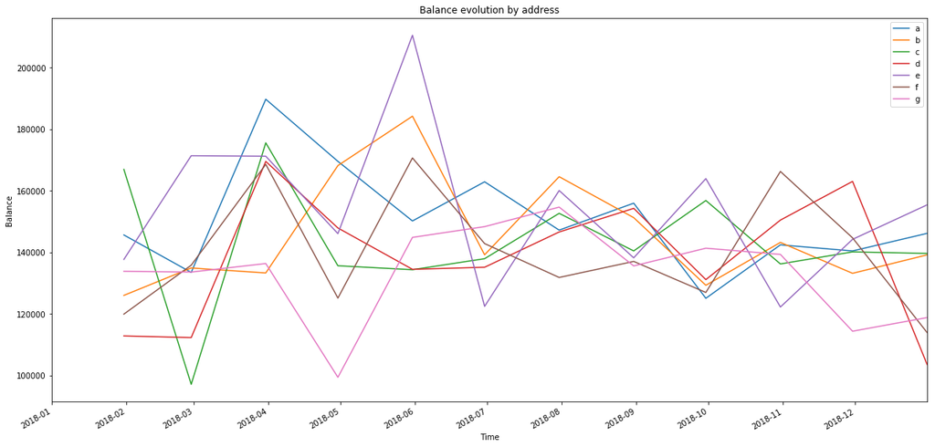

```python
fig, ax = plt.subplots()
fig.set_size_inches(20, 10)
ax.plot(aggregate_data_for_plot['dates'],aggregate_data_for_plot['a'])
ax.plot(aggregate_data_for_plot['dates'],aggregate_data_for_plot['b'])
ax.plot(aggregate_data_for_plot['dates'],aggregate_data_for_plot['c'])
ax.plot(aggregate_data_for_plot['dates'],aggregate_data_for_plot['d'])
ax.plot(aggregate_data_for_plot['dates'],aggregate_data_for_plot['e'])
ax.plot(aggregate_data_for_plot['dates'],aggregate_data_for_plot['f'])
ax.plot(aggregate_data_for_plot['dates'],aggregate_data_for_plot['g'])
fig.autofmt_xdate()
ax.set_xlim([datetime.date(2018, 1, 1), datetime.date(2018, 12, 31)])
plt.legend(loc='best')
plt.xlabel('Time')
plt.ylabel('Balance')
plt.title("Balance evolution by address")
```

```python
balance_data = pd.read_csv('balance_data.csv')
```

```python
balance_data.head()
```

|  | Unnamed: 0 | blocknumber | balance | address |
| --- | --- | --- | --- | --- |
| 0 | 0 | 66 | 1557 | g |
| 1 | 1 | 1265 | 1785 | e |
| 2 | 2 | 1353 | 1260 | a |
| 3 | 3 | 369 | 1957 | a |
| 4 | 4 | 1427 | 2760 | c |

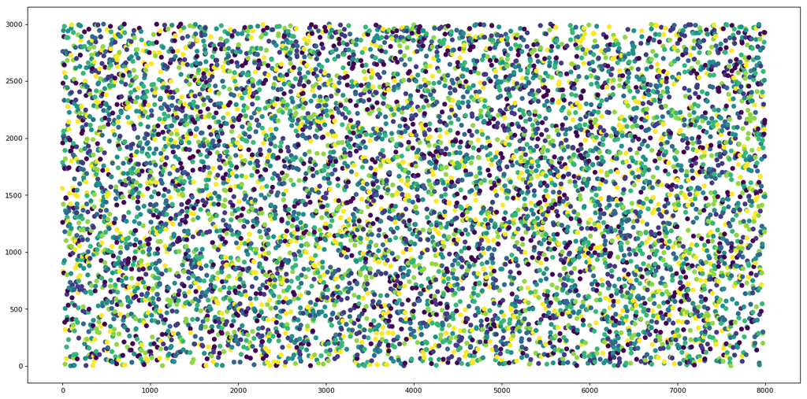

```python
plt.figure(figsize=(20, 10), dpi=80)
plt.scatter(balance_data.index, balance_data['balance'],
            c=balance_data['address'].astype('category').cat.codes)
```

Even though the points are cluttered, it is relatively visible that no particular clusters are found in the data.

2) Pick any two blockchains from https://coinmetrics.io/data-downloads/ and download their aggregate on-chain dataset (offerred in csv format) and produce an interesting visualization from the data. Feel free to use your imagination and don’t be restricted to just standard plots (bar, line, histogram etc). The goal is to display the data in a way such that the viewer can distinctly take away an insight from the dataset.

# **Cryptocurrency data visualization**

The analysis will focus on DASH and Bitcoin Cash

```python
dash_data = pd.read_csv('dash.csv')
bch = pd.read_csv('bch.csv')
```

```python
dash_data.head()
```

|  | date | txVolume(USD) | adjustedTxVolume(USD) | txCount | marketcap(USD) | price(USD) | exchangeVolume(USD) | realizedCap(USD) | generatedCoins | fees | activeAddresses | averageDifficulty | paymentCount | medianTxValue(USD) | medianFee | blockSize | blockCount |
| --- | --- | --- | --- | --- | --- | --- | --- | --- | --- | --- | --- | --- | --- | --- | --- | --- | --- |
| 0 | 2014-01-19 | NaN | NaN | 1151 | NaN | NaN | NaN | 0.0 | 1812104.0 | 0.6280 | 3691 | 0.274701 | 680 | NaN | 0.000 | 1272622 | 4138 |
| 1 | 2014-01-20 | NaN | NaN | 4239 | NaN | NaN | NaN | 0.0 | 201357.0 | 1.6935 | 4476 | 3.604337 | 4215 | NaN | 0.000 | 1189408 | 765 |
| 2 | 2014-01-21 | NaN | NaN | 2118 | NaN | NaN | NaN | 0.0 | 16840.0 | 1.7975 | 2262 | 4.717701 | 2118 | NaN | 0.001 | 631205 | 454 |
| 3 | 2014-01-22 | NaN | NaN | 267 | NaN | NaN | NaN | 0.0 | 2079.0 | 0.2260 | 338 | 6.106504 | 266 | NaN | 0.001 | 94905 | 99 |
| 4 | 2014-01-23 | NaN | NaN | 188 | NaN | NaN | NaN | 0.0 | 8729.0 | 0.1580 | 238 | 6.106504 | 187 | NaN | 0.001 | 74541 | 79 |

```python
dash_data.isna().sum()
dash_data = dash_data.replace(np.nan,0)
```

```python
dash_data["year"] = pd.to_datetime(dash_data["date"]).dt.year
```

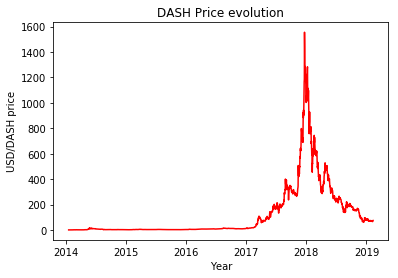

```python
ax = plt.subplot(111)
ax.plot(pd.to_datetime(dash_data['date']),dash_data['price(USD)'], color='r')
plt.xlabel('Year')
plt.ylabel('USD/DASH price')
plt.title('DASH Price evolution')
plt.show()
```

Below you can find several data visualizations based on the DASH and BCH Coinmetrics data. They are as follows:

```
1. Scatter plot of generatedCoins;
2. 2-d visualization of volume and generatedCoins
3. Feature correlation
4. Feature scatter plots and probability distributions
5. Market capitalization fluctuations for each coin
6. Cryptocurrency fee evolution
7. Cryptocurrency coin generation evolution
8. Probability distribution of prices for both dash and bitcoin cash
9. Show crypto price drivers (feature importance) for a portfolio comprised of both cryptocurrencies
10. Pie chart for portfolio generated coins
```

```python
dash_data["year"] = pd.to_datetime(dash_data["date"]).dt.year
```

## 1. Scatter plot of generatedCoins

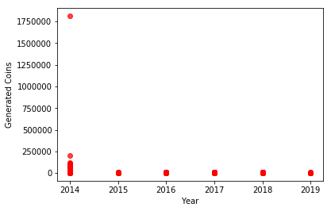

```python
plt.scatter(dash_data['year'],dash_data['generatedCoins'], color='r',alpha=0.75)
plt.xlabel('Year')
plt.ylabel('Generated Coins')
plt.show()
```

```python
dash_data[dash_data['generatedCoins'] > 1750000]
```

|  | date | txVolume(USD) | adjustedTxVolume(USD) | txCount | marketcap(USD) | price(USD) | exchangeVolume(USD) | realizedCap(USD) | generatedCoins | fees | activeAddresses | averageDifficulty | paymentCount | medianTxValue(USD) | medianFee | blockSize | blockCount | year |
| --- | --- | --- | --- | --- | --- | --- | --- | --- | --- | --- | --- | --- | --- | --- | --- | --- | --- | --- |
| 0 | 2014-01-19 | NaN | NaN | 1151 | NaN | NaN | NaN | 0.0 | 1812104.0 | 0.628 | 3691 | 0.274701 | 680 | NaN | 0.0 | 1272622 | 4138 | 2014 |

```python
dash_data['date'].sort_values()
```

```
0       2014-01-19
1       2014-01-20
2       2014-01-21
3       2014-01-22
4       2014-01-23
5       2014-01-24
6       2014-01-25
7       2014-01-26
8       2014-01-27
9       2014-01-28
10      2014-01-29
11      2014-01-30
12      2014-01-31
13      2014-02-01
14      2014-02-02
```

[output cut: 47 more lines]

That was just the first issue of Dash, hence not an anomaly

## 2-d visualization of volume and generatedCoins

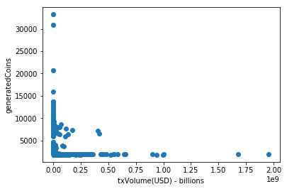

```python
import numpy as np
plt.scatter(dash_data['txVolume(USD)'],dash_data['generatedCoins'])
plt.xlabel('txVolume(USD) - billions')
plt.ylabel('generatedCoins')
plt.show()
```

```python
dash_data['txVolume(USD)'].sort_values().unique()
```

```
array([2.55781462e+04, 2.73845456e+04, 2.96558356e+04, ...,
       1.67531865e+09, 1.95554016e+09,            nan])
```

```python
bch.tail()
```

|  | date | txVolume(USD) | adjustedTxVolume(USD) | txCount | marketcap(USD) | price(USD) | exchangeVolume(USD) | realizedCap(USD) | generatedCoins | fees | activeAddresses | averageDifficulty | paymentCount | medianTxValue(USD) | medianFee | blockSize | blockCount |
| --- | --- | --- | --- | --- | --- | --- | --- | --- | --- | --- | --- | --- | --- | --- | --- | --- | --- |
| 564 | 2019-02-07 | 3.084208e+08 | 1.514443e+08 | 9712.0 | 2.028269e+09 | 115.18 | 192007562.0 | 5.380811e+09 | 1662.5 | 0.361411 | 20311.0 | 2.011470e+11 | 13214.0 | 3.460636 | 0.000004 | 4572071.0 | 133.0 |
| 565 | 2019-02-08 | 2.519079e+08 | 1.125384e+08 | 10038.0 | 2.039090e+09 | 115.78 | 392818315.0 | 5.379774e+09 | 1925.0 | 0.329761 | 21925.0 | 1.932464e+11 | 13638.0 | 4.160529 | 0.000004 | 4920884.0 | 154.0 |
| 566 | 2019-02-09 | 1.864789e+08 | 1.080649e+08 | 9936.0 | 2.288525e+09 | 129.93 | 233478378.0 | 5.377120e+09 | 1812.5 | 0.239865 | 21899.0 | 1.909177e+11 | 13174.0 | 2.719725 | 0.000003 | 4258437.0 | 145.0 |
| 567 | 2019-02-10 | 2.099621e+08 | 7.955368e+07 | 8534.0 | 2.265771e+09 | 128.63 | 285347998.0 | 5.373272e+09 | 1812.5 | 0.392639 | 20627.0 | 1.946868e+11 | 13103.0 | 6.052674 | 0.000004 | 3950907.0 | 145.0 |
| 568 | 2019-02-11 | 2.685892e+08 | 1.264120e+08 | 8770.0 | 2.249525e+09 | 127.69 | 282031883.0 | 5.358438e+09 | 1725.0 | 0.360107 | 20077.0 | 1.958199e+11 | 12741.0 | 3.784801 | 0.000004 | 4336161.0 | 138.0 |

```python
dash_data.tail()
```

|  | date | txVolume(USD) | adjustedTxVolume(USD) | txCount | marketcap(USD) | price(USD) | exchangeVolume(USD) | realizedCap(USD) | generatedCoins | fees | activeAddresses | averageDifficulty | paymentCount | medianTxValue(USD) | medianFee | blockSize | blockCount |
| --- | --- | --- | --- | --- | --- | --- | --- | --- | --- | --- | --- | --- | --- | --- | --- | --- | --- |
| 1844 | 2019-02-06 | 1.611686e+07 | 1.019879e+07 | 14196 | 5.888404e+08 | 68.34 | 188686597.0 | 2.131693e+09 | 1836.733417 | 2.119320 | 113410 | 7.161746e+07 | 80518 | 8.200882 | 0.000002 | 16058957 | 549 |
| 1845 | 2019-02-07 | 1.288122e+07 | 9.197728e+06 | 13672 | 5.666566e+08 | 65.75 | 151346662.0 | 2.129939e+09 | 1853.461408 | 1.798839 | 97267 | 7.007612e+07 | 65318 | 5.957335 | 0.000002 | 14073881 | 554 |
| 1846 | 2019-02-08 | 1.399612e+07 | 9.757393e+06 | 13435 | 5.798208e+08 | 67.26 | 181160600.0 | 2.130292e+09 | 1823.351024 | 2.532472 | 75556 | 7.897533e+07 | 47245 | 7.933815 | 0.000004 | 12227631 | 545 |
| 1847 | 2019-02-09 | 1.242350e+07 | 1.027378e+07 | 13614 | 6.368352e+08 | 73.86 | 169940905.0 | 2.129418e+09 | 1836.733417 | 2.331841 | 66067 | 7.371952e+07 | 42526 | 9.601896 | 0.000004 | 10291605 | 549 |
| 1848 | 2019-02-10 | 1.136870e+07 | 8.002844e+06 | 13405 | 6.402006e+08 | 74.24 | 177539073.0 | 2.128069e+09 | 1833.387819 | 1.545277 | 90469 | 7.530758e+07 | 64704 | 8.166482 | 0.000003 | 13766217 | 548 |

## 3. Feature correlation

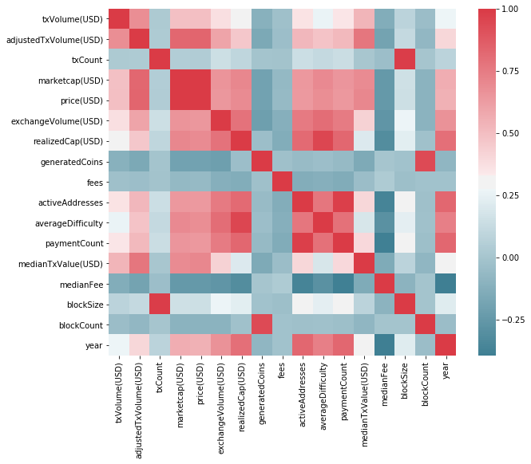

```python
#Correlation matrix
import seaborn as sns

f, ax = plt.subplots(figsize=(10, 8))
corr = dash_data.corr()
sns.heatmap(corr, mask=np.zeros_like(corr, dtype=np.bool), cmap=sns.diverging_palette(220, 10, as_cmap=True),
            square=True, ax=ax)
```

```python
dash_data.corr()
```

|  | txVolume(USD) | adjustedTxVolume(USD) | txCount | marketcap(USD) | price(USD) | exchangeVolume(USD) | realizedCap(USD) | generatedCoins | fees | activeAddresses | averageDifficulty | paymentCount | medianTxValue(USD) | medianFee | blockSize | blockCount | year |
| --- | --- | --- | --- | --- | --- | --- | --- | --- | --- | --- | --- | --- | --- | --- | --- | --- | --- |
| txVolume(USD) | 1.000000 | 0.682092 | 0.026238 | 0.493454 | 0.498218 | 0.374542 | 0.277500 | -0.111760 | -0.026402 | 0.360414 | 0.263210 | 0.351476 | 0.534331 | -0.132822 | 0.085003 | -0.044831 | 0.273487 |
| adjustedTxVolume(USD) | 0.682092 | 1.000000 | 0.031229 | 0.828315 | 0.834002 | 0.600978 | 0.464595 | -0.158701 | -0.034856 | 0.521997 | 0.479091 | 0.518816 | 0.772006 | -0.186888 | 0.118087 | -0.073511 | 0.402488 |
| txCount | 0.026238 | 0.031229 | 1.000000 | 0.049519 | 0.047074 | 0.147716 | 0.101746 | -0.004332 | -0.010383 | 0.142833 | 0.115183 | 0.135456 | 0.007781 | -0.034327 | 0.985386 | -0.000709 | 0.085316 |
| marketcap(USD) | 0.493454 | 0.828315 | 0.049519 | 1.000000 | 0.999652 | 0.658330 | 0.709417 | -0.194765 | -0.062712 | 0.644781 | 0.696915 | 0.652362 | 0.691875 | -0.245264 | 0.153441 | -0.101894 | 0.560401 |
| price(USD) | 0.498218 | 0.834002 | 0.047074 | 0.999652 | 1.000000 | 0.648847 | 0.693178 | -0.193839 | -0.061072 | 0.636428 | 0.680551 | 0.643830 | 0.707012 | -0.242005 | 0.149893 | -0.101530 | 0.550868 |
| exchangeVolume(USD) | 0.374542 | 0.600978 | 0.147716 | 0.658330 | 0.648847 | 1.000000 | 0.782608 | -0.210967 | -0.120362 | 0.755736 | 0.804429 | 0.751350 | 0.426954 | -0.264867 | 0.266639 | -0.100480 | 0.664023 |
| realizedCap(USD) | 0.277500 | 0.464595 | 0.101746 | 0.709417 | 0.693178 | 0.782608 | 1.000000 | -0.039624 | -0.137498 | 0.818732 | 0.956142 | 0.828610 | 0.210155 | -0.314942 | 0.231620 | -0.020735 | 0.797861 |
| generatedCoins | -0.111760 | -0.158701 | -0.004332 | -0.194765 | -0.193839 | -0.210967 | -0.039624 | 1.000000 | -0.026468 | -0.053877 | -0.034563 | -0.058020 | -0.152875 | 0.003354 | -0.013877 | 0.936928 | -0.080104 |
| fees | -0.026402 | -0.034856 | -0.010383 | -0.062712 | -0.061072 | -0.120362 | -0.137498 | -0.026468 | 1.000000 | -0.127111 | -0.117974 | -0.139421 | -0.041292 | 0.035110 | -0.030882 | -0.013275 | -0.015352 |
| activeAddresses | 0.360414 | 0.521997 | 0.142833 | 0.644781 | 0.636428 | 0.755736 | 0.818732 | -0.053877 | -0.127111 | 1.000000 | 0.774297 | 0.979586 | 0.405597 | -0.361875 | 0.301228 | -0.025951 | 0.827217 |
| averageDifficulty | 0.263210 | 0.479091 | 0.115183 | 0.696915 | 0.680551 | 0.804429 | 0.956142 | -0.034563 | -0.117974 | 0.774297 | 1.000000 | 0.788176 | 0.188454 | -0.287360 | 0.236871 | -0.018353 | 0.735247 |
| paymentCount | 0.351476 | 0.518816 | 0.135456 | 0.652362 | 0.643830 | 0.751350 | 0.828610 | -0.058020 | -0.139421 | 0.979586 | 0.788176 | 1.000000 | 0.397057 | -0.383093 | 0.292713 | -0.030264 | 0.827065 |
| medianTxValue(USD) | 0.534331 | 0.772006 | 0.007781 | 0.691875 | 0.707012 | 0.426954 | 0.210155 | -0.152875 | -0.041292 | 0.405597 | 0.188454 | 0.397057 | 1.000000 | -0.145707 | 0.081789 | -0.079467 | 0.322699 |
| medianFee | -0.132822 | -0.186888 | -0.034327 | -0.245264 | -0.242005 | -0.264867 | -0.314942 | 0.003354 | 0.035110 | -0.361875 | -0.287360 | -0.383093 | -0.145707 | 1.000000 | -0.095230 | -0.004403 | -0.393474 |
| blockSize | 0.085003 | 0.118087 | 0.985386 | 0.153441 | 0.149893 | 0.266639 | 0.231620 | -0.013877 | -0.030882 | 0.301228 | 0.236871 | 0.292713 | 0.081789 | -0.095230 | 1.000000 | -0.004793 | 0.221561 |
| blockCount | -0.044831 | -0.073511 | -0.000709 | -0.101894 | -0.101530 | -0.100480 | -0.020735 | 0.936928 | -0.013275 | -0.025951 | -0.018353 | -0.030264 | -0.079467 | -0.004403 | -0.004793 | 1.000000 | -0.044794 |
| year | 0.273487 | 0.402488 | 0.085316 | 0.560401 | 0.550868 | 0.664023 | 0.797861 | -0.080104 | -0.015352 | 0.827217 | 0.735247 | 0.827065 | 0.322699 | -0.393474 | 0.221561 | -0.044794 | 1.000000 |

## 4. Feature scatter plots and probability distributions

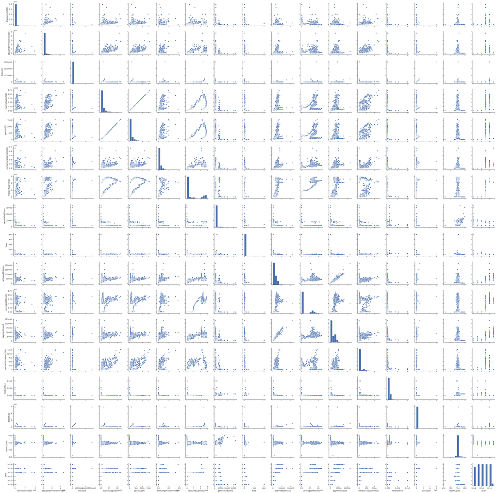

```python
sns.set(style="ticks", color_codes=True)
sns.pairplot(dash_data.dropna())
```

The figure above can be used as a reference for quickly plotting scatter plots or probability distributions between two variables

## 5.Market capitalization fluctuations for each coin

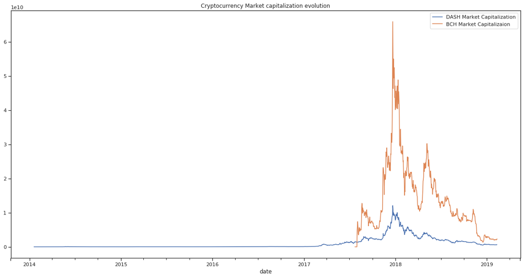

```python
plt.figure(figsize=(20,10))
dash_data.groupby('date')['marketcap(USD)'].sum().plot(label='DASH Market Capitalization')
bch.groupby('date')['marketcap(USD)'].sum().plot(label='BCH Market Capitalizaion')
plt.legend(loc='best')
plt.title("Cryptocurrency Market capitalization evolution")
```

## 6. Cryptocurrency fee evolution

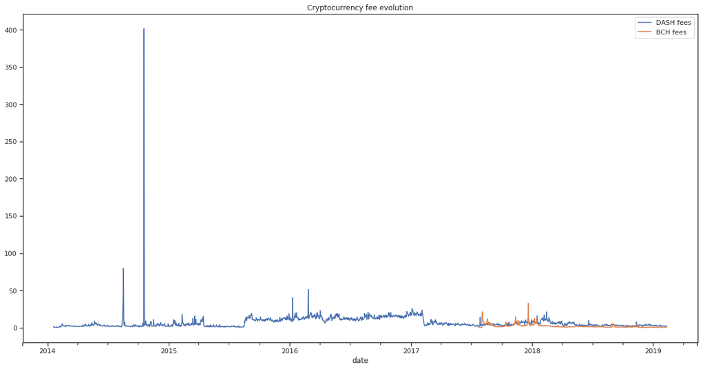

```python
plt.figure(figsize=(20,10))
dash_data.groupby('date')['fees'].sum().plot(label='DASH fees')
bch.groupby('date')['fees'].sum().plot(label='BCH fees')
plt.legend(loc='best')
plt.title("Cryptocurrency fee evolution")
```

## 7.Cryptocurrency coin generation evolution

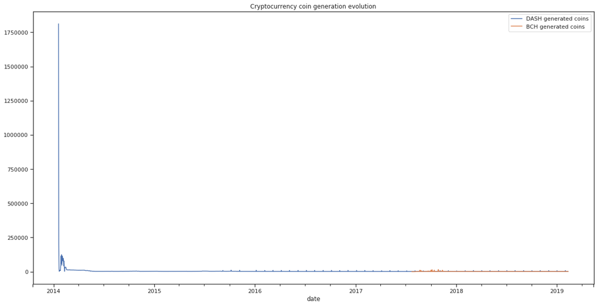

```python
dash_data['date']=pd.to_datetime(dash_data['date'])
bch['date']=pd.to_datetime(bch['date'])
plt.figure(figsize=(20,10))
dash_data.groupby('date')['generatedCoins'].sum().plot(label='DASH generated coins')
bch.groupby('date')['generatedCoins'].sum().plot(label='BCH generated coins')
plt.legend(loc='best')
plt.title("Cryptocurrency coin generation evolution")
```

## 8. Probability distribution of prices for both dash and bitcoin cash

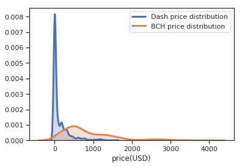

```python
sns.distplot(dash_data['price(USD)'], hist = False, kde = True,
                 kde_kws = {'shade': True, 'linewidth': 3},
                  label = 'Dash price distribution')
sns.distplot(bch['price(USD)'], hist = False, kde = True,
                 kde_kws = {'shade': True, 'linewidth': 3},
                  label = 'BCH price distribution')
```

```python
dash_data.describe()
```

|  | txVolume(USD) | adjustedTxVolume(USD) | txCount | marketcap(USD) | price(USD) | exchangeVolume(USD) | realizedCap(USD) | generatedCoins | fees | activeAddresses | averageDifficulty | paymentCount | medianTxValue(USD) | medianFee | blockSize | blockCount | year |
| --- | --- | --- | --- | --- | --- | --- | --- | --- | --- | --- | --- | --- | --- | --- | --- | --- | --- |
| count | 1.823000e+03 | 1.823000e+03 | 1.849000e+03 | 1.823000e+03 | 1823.000000 | 1.823000e+03 | 1.849000e+03 | 1.849000e+03 | 1849.000000 | 1849.000000 | 1.849000e+03 | 1849.000000 | 1823.000000 | 1849.000000 | 1.849000e+03 | 1849.000000 | 1849.000000 |
| mean | 3.234941e+07 | 1.449118e+07 | 6.539661e+03 | 9.516702e+08 | 121.777218 | 4.622585e+07 | 6.904399e+08 | 4.666315e+03 | 6.932946 | 22046.509465 | 1.758539e+07 | 15651.307193 | 83.601006 | 0.000316 | 4.428226e+06 | 551.244997 | 2016.085992 |
| std | 9.893029e+07 | 3.166794e+07 | 7.185073e+04 | 1.716309e+09 | 218.909068 | 8.044875e+07 | 1.045065e+09 | 4.296086e+04 | 10.786987 | 20200.979537 | 3.068171e+07 | 13931.938931 | 156.145124 | 0.000605 | 1.422992e+07 | 90.313853 | 1.458912 |
| min | 2.557815e+04 | 2.042434e+04 | 1.880000e+02 | 7.054869e+05 | 0.213899 | 9.604000e+03 | 0.000000e+00 | 1.796586e+03 | 0.083000 | 238.000000 | 2.747009e-01 | 187.000000 | 0.046531 | 0.000000 | 7.454100e+04 | 64.000000 | 2014.000000 |
| 25% | 3.913373e+05 | 2.869621e+05 | 1.283000e+03 | 1.575685e+07 | 2.915000 | 1.077205e+05 | 1.797939e+07 | 1.974418e+03 | 2.547224 | 7519.000000 | 3.234269e+03 | 4821.000000 | 8.870011 | 0.000007 | 1.534191e+06 | 546.000000 | 2015.000000 |
| 50% | 1.416114e+06 | 9.103573e+05 | 1.967000e+03 | 6.158346e+07 | 9.510000 | 7.482650e+05 | 3.451358e+07 | 2.141816e+03 | 4.345235 | 11629.000000 | 1.883766e+04 | 8728.000000 | 16.422783 | 0.000097 | 2.403370e+06 | 549.000000 | 2016.000000 |
| 75% | 2.666976e+07 | 1.570980e+07 | 6.462000e+03 | 1.352362e+09 | 172.220000 | 7.543010e+07 | 9.520116e+08 | 2.885071e+03 | 10.696230 | 37577.000000 | 2.313944e+07 | 26557.000000 | 45.164220 | 0.000451 | 6.350588e+06 | 552.000000 | 2017.000000 |
| max | 1.955540e+09 | 4.662284e+08 | 3.021835e+06 | 1.208263e+10 | 1555.590000 | 9.415441e+08 | 2.898362e+09 | 1.812104e+06 | 401.515000 | 223761.000000 | 1.180850e+08 | 116426.000000 | 1282.033292 | 0.010000 | 5.847418e+08 | 4138.000000 | 2019.000000 |

```python
bch.describe()
```

|  | txVolume(USD) | adjustedTxVolume(USD) | txCount | marketcap(USD) | price(USD) | exchangeVolume(USD) | realizedCap(USD) | generatedCoins | fees | activeAddresses | averageDifficulty | paymentCount | medianTxValue(USD) | medianFee | blockSize | blockCount |
| --- | --- | --- | --- | --- | --- | --- | --- | --- | --- | --- | --- | --- | --- | --- | --- | --- |
| count | 5.580000e+02 | 5.580000e+02 | 5.580000e+02 | 5.690000e+02 | 569.000000 | 5.690000e+02 | 5.600000e+02 | 558.000000 | 558.000000 | 558.000000 | 5.580000e+02 | 5.580000e+02 | 558.000000 | 558.000000 | 5.580000e+02 | 558.000000 |
| mean | 7.508463e+08 | 3.529668e+08 | 4.572873e+04 | 1.383921e+10 | 819.901670 | 6.912733e+08 | 8.019114e+09 | 2033.400272 | 2.141448 | 50589.204301 | 3.644253e+11 | 4.082513e+04 | 345.479401 | 0.000020 | 2.212406e+07 | 162.672043 |
| std | 1.336713e+09 | 4.662524e+08 | 1.705079e+05 | 1.077359e+10 | 631.659761 | 9.287833e+08 | 3.476215e+09 | 1572.824461 | 2.706400 | 48456.414724 | 2.016218e+11 | 1.879144e+05 | 470.115456 | 0.000041 | 5.587243e+07 | 125.825953 |
| min | 3.343032e+07 | 2.962058e+07 | 3.818000e+03 | 0.000000e+00 | 77.370000 | 8.501300e+04 | 2.149804e+08 | 162.500000 | 0.090489 | 9628.000000 | 4.774082e+10 | 4.977000e+03 | 0.000000 | 0.000002 | 2.193624e+06 | 13.000000 |
| 25% | 1.885302e+08 | 1.189900e+08 | 1.175500e+04 | 7.003506e+09 | 420.470000 | 2.728560e+08 | 5.397615e+09 | 1715.625000 | 0.739247 | 29472.250000 | 1.846630e+11 | 1.419225e+04 | 8.853134 | 0.000003 | 6.663210e+06 | 137.250000 |
| 50% | 3.143778e+08 | 1.811479e+08 | 1.718700e+04 | 1.062149e+10 | 627.060000 | 4.122790e+08 | 1.016524e+10 | 1800.000000 | 1.257777 | 39973.000000 | 3.466216e+11 | 2.379100e+04 | 115.595008 | 0.000004 | 9.030704e+06 | 144.000000 |
| 75% | 6.705379e+08 | 3.326927e+08 | 2.399975e+04 | 1.971220e+10 | 1159.890000 | 7.774200e+08 | 1.079604e+10 | 1887.500000 | 2.469042 | 51149.000000 | 5.576153e+11 | 3.024100e+04 | 540.733068 | 0.000013 | 1.303539e+07 | 151.000000 |
| max | 1.393658e+10 | 3.908636e+09 | 2.103739e+06 | 6.594014e+10 | 3909.000000 | 1.188960e+10 | 1.154897e+10 | 15675.000000 | 32.781486 | 428452.000000 | 8.832170e+11 | 3.422954e+06 | 2949.054899 | 0.000339 | 5.994620e+08 | 1254.000000 |

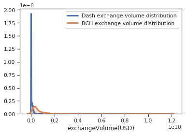

```python
sns.distplot(dash_data['exchangeVolume(USD)'], hist = False, kde = True,
                 kde_kws = {'shade': True, 'linewidth': 3},
                  label = 'Dash exchange volume distribution')
sns.distplot(bch['exchangeVolume(USD)'], hist = False, kde = True,
                 kde_kws = {'shade': True, 'linewidth': 3},
                  label = 'BCH exchange volume distribution')
```

## 9. Show crypto price drivers (feature importance) for a portfolio comprised of both cryptocurrencies

```python
#merge data
dash_data['currency']='DASH'
bch['currency']='BCH'
cryptocurrency_data= pd.concat([dash_data,bch])
cryptocurrency_data=cryptocurrency_data.set_index('date')
```

```python
cryptocurrency_data.isna().sum()
```

```
txVolume(USD)            37
adjustedTxVolume(USD)    37
txCount                  11
marketcap(USD)           26
price(USD)               26
exchangeVolume(USD)      26
realizedCap(USD)          9
generatedCoins           11
fees                     11
activeAddresses          11
averageDifficulty        11
paymentCount             11
medianTxValue(USD)       37
medianFee                11
blockSize                11
blockCount               11
currency                  0
dtype: int64
```

```python
cryptocurrency_data = cryptocurrency_data.replace(np.nan,0)
cryptocurrency_data['currency']=cryptocurrency_data['currency'].replace({'DASH':0,'BCH':1})
```

```python
#Set features and target data
from sklearn.ensemble import RandomForestRegressor
from sklearn import datasets
from sklearn.model_selection import train_test_split
from sklearn.feature_selection import SelectFromModel
from sklearn.metrics import accuracy_score
X=cryptocurrency_data.loc[:, cryptocurrency_data.columns != 'price(USD)']
y=cryptocurrency_data['price(USD)']

# Split the data into 40% test and 60% training
X_train, X_test, y_train, y_test = train_test_split(X, y, test_size=0.4, random_state=0)
# Create a random forest regressor
reg = RandomForestRegressor(n_estimators=5000, random_state=0, n_jobs=-1)
```

```python
# Train the regressor
reg.fit(X_train, y_train)
```

```
RandomForestRegressor(bootstrap=True, criterion='mse', max_depth=None,
           max_features='auto', max_leaf_nodes=None,
           min_impurity_decrease=0.0, min_impurity_split=None,
           min_samples_leaf=1, min_samples_split=2,
           min_weight_fraction_leaf=0.0, n_estimators=5000, n_jobs=-1,
           oob_score=False, random_state=0, verbose=0, warm_start=False)
```

```python
#Show feature importance based on the Gini index.
gini_importance = pd.DataFrame(list(zip(cryptocurrency_data.columns.tolist(), clf.feature_importances_)),columns=['features','Gini importance'])
gini_importance = gini_importance.drop([8])
sorted_gini_importance = gini_importance.sort_values('Gini importance',ascending=False)
```

```python
sorted_gini_importance
```

[output not shown]

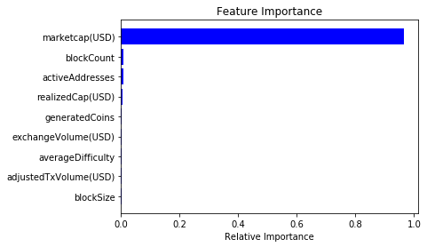

```python
import matplotlib.pyplot as plt
features = cryptocurrency_data.columns
importances = reg.feature_importances_
indices = np.argsort(importances)[-9:]  # top 10 features
plt.title('Feature Importance')
plt.barh(range(len(indices)), importances[indices], color='b', align='center')
plt.yticks(range(len(indices)), [features[i] for i in indices])
plt.xlabel('Relative Importance')
plt.show()
```

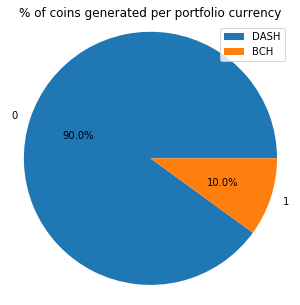

```python
#8.pie chart for portfolio generated coins
labels = cryptocurrency_data['currency'].astype('category').cat.categories.tolist()
counts = cryptocurrency_data['generatedCoins']
sizes = [counts[var_cat] for var_cat in labels]
fig1, ax1 = plt.subplots(figsize=(5,5))
ax1.pie(sizes, labels=labels, autopct='%1.1f%%',radius=100000) #autopct is show the % on plot
ax1.axis('equal')
plt.title('% of coins generated per portfolio currency')
plt.legend({'BCH','DASH'})
plt.show()
```

```python
#10. Aim to predict cryptocurency prices
y_pred =reg.predict(X_test)
```

```python
#Root Mean Squared Error
from sklearn.metrics import mean_squared_error
mean_squared_error(y_test, y_pred)
```

```
677.4584254856411
```

```python
prices=pd.DataFrame(y_test)
prices['pred']=y_pred
```

```python
prices
```

| date | price(USD) | pred |
| --- | --- | --- |
| 2018-11-14 | 511.63 | 534.082416 |
| 2018-10-27 | 155.38 | 153.899002 |
| 2016-04-08 | 6.88 | 6.792540 |
| 2018-01-04 | 2608.87 | 2609.031514 |
| 2015-09-29 | 2.38 | 2.375724 |
| 2017-08-11 | 200.82 | 198.653390 |
| 2018-01-12 | 1013.06 | 948.745820 |
| 2019-02-04 | 119.30 | 120.010242 |
| 2019-01-19 | 128.55 | 129.015732 |
| 2016-02-01 | 4.11 | 4.103120 |
| 2017-01-14 | 12.59 | 12.904726 |
| 2015-10-27 | 2.24 | 2.329150 |
| 2016-03-22 | 5.97 | 6.055170 |
| 2018-01-18 | 1752.27 | 1780.594818 |
| 2019-01-08 | 83.45 | 87.288840 |
| 2018-04-01 | 688.01 | 698.779326 |
| 2015-11-17 | 2.32 | 2.314340 |
| 2017-10-01 | 433.38 | 439.580564 |
| 2018-01-10 | 1115.48 | 1103.339460 |
| 2017-05-08 | 106.55 | 102.844792 |
| 2016-04-04 | 7.00 | 6.973546 |
| 2016-11-07 | 9.40 | 9.393130 |
| 2016-06-19 | 8.16 | 8.216008 |
| 2015-11-01 | 2.31 | 2.336324 |
| 2017-06-20 | 201.37 | 198.772638 |
| 2018-01-27 | 1602.50 | 1614.336534 |
| 2018-01-06 | 1157.09 | 1128.483482 |
| 2015-02-13 | 2.82 | 2.742734 |
| 2017-11-12 | 345.68 | 355.244626 |
| 2018-02-03 | 589.17 | 589.865056 |
| ... | ... | ... |
| 2017-07-30 | 385.14 | 420.380324 |
| 2017-03-04 | 47.17 | 41.262248 |
| 2015-01-05 | 1.63 | 1.636578 |
| 2017-11-10 | 651.78 | 705.495862 |
| 2018-01-16 | 2406.86 | 2486.147656 |
| 2018-10-22 | 447.19 | 449.869896 |
| 2017-09-16 | 284.51 | 280.232640 |
| 2018-11-13 | 514.58 | 529.274784 |
| 2017-08-30 | 549.32 | 539.248008 |
| 2018-02-19 | 1483.34 | 1486.623240 |
| 2015-05-02 | 2.74 | 2.764898 |
| 2016-04-09 | 6.98 | 6.929060 |
| 2017-09-21 | 342.41 | 335.210488 |
| 2015-07-07 | 3.09 | 3.075396 |
| 2016-09-22 | 11.54 | 11.569740 |
| 2015-05-13 | 2.72 | 2.752782 |
| 2017-01-31 | 15.93 | 15.661682 |
| 2015-11-15 | 2.38 | 2.418338 |
| 2017-01-03 | 11.81 | 12.183482 |
| 2018-09-05 | 626.20 | 629.651848 |
| 2014-10-17 | 2.18 | 2.164540 |
| 2016-01-15 | 3.36 | 3.501674 |
| 2015-06-19 | 2.96 | 2.949898 |
| 2018-02-12 | 582.83 | 587.672320 |
| 2018-10-01 | 187.17 | 188.314094 |
| 2017-10-19 | 339.27 | 330.656292 |
| 2015-03-06 | 3.41 | 3.442798 |
| 2017-08-12 | 206.22 | 198.663184 |
| 2017-05-25 | 143.20 | 143.766262 |
| 2016-07-17 | 8.25 | 8.345884 |

968 rows × 2 columns

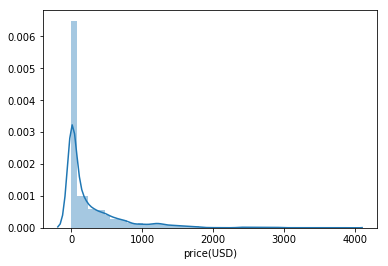

```python
import seaborn as sns
sns.distplot(cryptocurrency_data['price(USD)'])
```